# Metabolites that identify MASH with normal ALT

### Metabolon annotation

```r
sig <- res_alt_norm$results
idx <- match(rownames(sig), chemical_details$CHEMICAL_NAME)
cat("Unannotated:", sum(is.na(idx)), "/", nrow(sig), "\n")
```

```
## Unannotated: 0 / 139
```

```r
sig$Super_pathway <- chemical_details$SUPER_PATHWAY[idx]
sig$Sub_pathway   <- chemical_details$SUB_PATHWAY[idx]
sig$metabolite    <- rownames(sig)

sig_show <- sig[, c("Super_pathway", "Sub_pathway", "logFC", "FC", "adj.P.Val")]

datatable(sig_show,
          caption = "MASH vs no-MASH, normal ALT — Metabolon annotation",
          options = list(scrollX = TRUE))
```

|  | Super_pathway | Sub_pathway | logFC | FC | adj.P.Val |
| --- | --- | --- | --- | --- | --- |
| palmitoyl-arachidonoyl-glycerol (16:0/20:4) [1]* | Lipid | Diacylglycerol | 1.298582 | 2.46 | 0 |
| 1-carboxyethylphenylalanine | Amino Acid | Phenylalanine Metabolism | 0.782756 | 1.72 | 0 |
| 1-carboxyethylvaline | Amino Acid | Leucine, Isoleucine and Valine Metabolism | 0.861228 | 1.82 | 0 |
| stearoyl-arachidonoyl-glycerol (18:0/20:4) [1]* | Lipid | Diacylglycerol | 0.643921 | 1.56 | 0 |
| glucose | Carbohydrate | Glycolysis, Gluconeogenesis, and Pyruvate Metabolism | 0.352823 | 1.28 | 0 |
| methionine sulfone | Amino Acid | Methionine, Cysteine, SAM and Taurine Metabolism | 0.654169 | 1.57 | 0 |
| alpha-ketoglutarate | Energy | TCA Cycle | 0.271112 | 1.21 | 0 |
| N-stearoyl-sphingosine (d18:1/18:0)* | Lipid | Ceramides | 0.40044 | 1.32 | 0 |
| 1-carboxyethylisoleucine | Amino Acid | Leucine, Isoleucine and Valine Metabolism | 0.809361 | 1.75 | 0 |
| oleoyl-arachidonoyl-glycerol (18:1/20:4) [1]* | Lipid | Diacylglycerol | 0.737463 | 1.67 | 0 |

[output cut: 129 more lines]

### Summary by sub-pathway

```r
# Sorted by |logFC| first, so `Strongest` really lists the strongest hits.
sub_sum <- sig %>%
  arrange(desc(abs(logFC))) %>%
  group_by(Super_pathway, Sub_pathway) %>%
  summarise(
    No_Sig    = n(),
    No_Up     = sum(logFC > 0),
    No_Down   = sum(logFC < 0),
    Direction = case_when(
      all(logFC > 0) ~ "All \u2191",
      all(logFC < 0) ~ "All \u2193",
      TRUE ~ paste0(sum(logFC > 0), "\u2191 / ", sum(logFC < 0), "\u2193")
    ),
    Strongest = paste(head(metabolite, 3), collapse = "; "),
    .groups   = "drop"
  ) %>%
  arrange(desc(No_Sig))

datatable(sub_sum, options = list(scrollX = TRUE),
          caption = "Significant metabolites by Metabolon sub-pathway")
```

|  | Super_pathway | Sub_pathway | No_Sig | No_Up | No_Down | Direction | Strongest |
| --- | --- | --- | --- | --- | --- | --- | --- |
| 1 | Lipid | Diacylglycerol | 22 | 22 | 0 | All ↑ | palmitoyl-arachidonoyl-glycerol (16:0/20:4) [1]*; palmitoyl-arachidonoyl-glycerol (16:0/20:4) [2]*; palmitoyl-oleoyl-glycerol (16:0/18:1) [2]* |
| 2 | Lipid | Phosphatidylethanolamine (PE) | 8 | 8 | 0 | All ↑ | 1-stearoyl-2-oleoyl-GPE (18:0/18:1); 1-palmitoyl-2-oleoyl-GPE (16:0/18:1); 1-palmitoyl-2-arachidonoyl-GPE (16:0/20:4)* |
| 3 | Lipid | Primary Bile Acid Metabolism | 8 | 8 | 0 | All ↑ | taurocholate; cholate; taurochenodeoxycholate |
| 4 | Lipid | Fatty Acid, Dicarboxylate | 7 | 7 | 0 | All ↑ | 3-hydroxydodecanedioate*; tetradecanedioate (C14-DC); hexadecanedioate (C16-DC) |
| 5 | Amino Acid | Leucine, Isoleucine and Valine Metabolism | 6 | 6 | 0 | All ↑ | 1-carboxyethylvaline; 1-carboxyethylisoleucine; 1-carboxyethylleucine |
| 6 | Lipid | Long Chain Polyunsaturated Fatty Acid (n3 and n6) | 5 | 5 | 0 | All ↑ | docosatrienoate (22:3n6)*; adrenate (22:4n6); docosapentaenoate (n3 DPA; 22:5n3) |
| 7 | Amino Acid | Glutamate Metabolism | 4 | 3 | 1 | 3↑ / 1↓ | beta-citrylglutamate; glutamate; 4-hydroxyglutamate |
| 8 | Amino Acid | Methionine, Cysteine, SAM and Taurine Metabolism | 4 | 4 | 0 | All ↑ | methionine sulfone; alpha-ketobutyrate; lanthionine |
| 9 | Amino Acid | Tyrosine Metabolism | 4 | 4 | 0 | All ↑ | p-cresol glucuronide*; 1-carboxyethyltyrosine; dopamine 4-sulfate |
| 10 | Carbohydrate | Glycolysis, Gluconeogenesis, and Pyruvate Metabolism | 4 | 3 | 1 | 3↑ / 1↓ | pyruvate; 1,5-anhydroglucitol (1,5-AG); glucose |

[output cut: 36 more lines]

## A4. Logistic regression: ALT alone vs metabolite alone vs ALT + metabolite

### Data prep (RINT)

```r
## RINT is applied to every metabolite BEFORE any outcome is examined,
## so it cannot leak outcome information.

work_aligned   <- work
plasma_aligned <- as.data.frame(t(plasma_sub))          # samples x metabolites
plasma_aligned <- plasma_aligned[work_aligned$patient, , drop = FALSE]

# Rank-based inverse normal transform
rint <- function(x) {
  n <- sum(!is.na(x))
  if (n < 3) return(x)
  qnorm((rank(x, na.last = "keep") - 0.5) / n)
}
plasma_aligned <- as.data.frame(lapply(plasma_aligned, rint))
rownames(plasma_aligned) <- work_aligned$patient        # lapply() drops row names

# Metabolite names: clean for modelling, keep a map back to the originals
orig_metabolites  <- rownames(plasma_sub)
clean_metabolites <- make.names(orig_metabolites)
colnames(plasma_aligned) <- clean_metabolites
name_map <- setNames(orig_metabolites, clean_metabolites)

# Modelling frames: built AFTER the transform
df_all <- work_aligned %>%
  select(patient, mash_lab, ALT, alt_level, sex) %>%
  cbind(plasma_aligned[work_aligned$patient, , drop = FALSE]) %>%
  filter(!is.na(mash_lab), !is.na(ALT))

df_norm <- df_all %>% filter(alt_level == "normal")

# Verify the transform reached the modelling frame
stopifnot(max(abs(df_norm[[clean_metabolites[1]]]), na.rm = TRUE) < 4)

cat("All patients:", nrow(df_all),
    "| Normal-ALT patients:", nrow(df_norm), "\n")
```

```
## All patients: 1248 | Normal-ALT patients: 872
```

```r
cat("Max |z| in df_norm:",
    round(max(abs(as.matrix(df_norm[, clean_metabolites])), na.rm = TRUE), 2), "\n")
```

```
## Max |z| in df_norm: 3.35
```

### Run

Currently disabled (`eval=FALSE`). Set `eval=TRUE` on this chunk to run it.

```r
res_norm <- run_alt_vs_met(df_norm)

if (any(res_norm$separation_warning)) {
  warning(sum(res_norm$separation_warning),
          " metabolite(s) show quasi-separation (SE > 5); ORs unstable.")
}

tbl1(res_norm)
tbl2(res_norm)
tbl3(res_norm, cv_auc_min = 0.70, fdr_max = 0.05)
```

# Part B — Selected metabolites across clusters (CTRL vs CM vs LS)

Selected metabolites compared across the CTRL / CM / LS clusters: pairwise Wilcoxon rank-sum tests (Holm-adjusted within each metabolite), shown as per-metabolite boxplots with significance brackets.

Plotting helpers (`stars_from_p`, `make_plot`) live in `functions_plotting_clusters.R`, sourced above.

## B1. Metabolites of interest

```r
met_list <- c(
  "1-carboxyethylvaline",
  "glycochenodeoxycholate glucuronide (1)",
  "palmitoyl-arachidonoyl-glycerol (16:0/20:4) [2]*",
  "palmitoyl-arachidonoyl-glycerol (16:0/20:4) [1]*",
  "homocitrulline",
  "cholic acid glucuronide",
  "palmitoyl-oleoyl-glycerol (16:0/18:1) [2]*",
  "palmitoyl-oleoyl-glycerol (16:0/18:1) [1]*",
  "deoxycholic acid glucuronide",
  "1-carboxyethylisoleucine",
  "1,5-anhydroglucitol (1,5-AG)"
)

missing_mets <- setdiff(met_list, rownames(plasma_data))
if (length(missing_mets) > 0) {
  stop("Not in rownames(plasma_data): ", paste(missing_mets, collapse = ", "))
}
```

## B2. Long-format table

```r
plasma_t        <- as.data.frame(t(plasma_data[met_list, , drop = FALSE]))
plasma_t$sample <- rownames(plasma_t)

cluster_data$sample <- rownames(cluster_data)

# Column of cluster_data holding CTRL / CM / LS
class_col <- "class"
stopifnot(class_col %in% colnames(cluster_data))

long <- plasma_t %>%
  left_join(
    cluster_data %>% select(sample, class = all_of(class_col)),
    by = "sample"
  ) %>%
  filter(!is.na(class)) %>%
  pivot_longer(
    cols      = all_of(met_list),
    names_to  = "Metabolite",
    values_to = "value"
  ) %>%
  mutate(class = factor(class, levels = c("CTRL", "CM", "LS")))

cat("long built:", nrow(long), "rows |",
    dplyr::n_distinct(long$sample), "samples |",
    dplyr::n_distinct(long$Metabolite), "metabolites\n")
```

```
## long built: 14531 rows | 1321 samples | 11 metabolites
```

```r
print(table(unique(long[, c("sample", "class")])$class))   # group sizes
```

```
##
## CTRL   CM   LS
## 1075  151   95
```

```r
grp_levels <- levels(long$class)
```

## B3. Pairwise tests and bracket positions

```r
pw <- long %>%
  group_by(Metabolite) %>%
  group_modify(~ {
    res <- pairwise.wilcox.test(.x$value, .x$class,
                                p.adjust.method = "holm", exact = FALSE)
    as.data.frame(as.table(res$p.value)) %>%
      setNames(c("g2", "g1", "p_adj")) %>%
      filter(!is.na(p_adj))
  }) %>%
  ungroup() %>%
  mutate(
    g1    = as.character(g1),
    g2    = as.character(g2),
    stars = stars_from_p(p_adj),
    x1    = match(g1, grp_levels),
    x2    = match(g2, grp_levels)
  ) %>%
  mutate(                                   # ensure x1 < x2
    lo = pmin(x1, x2), hi = pmax(x1, x2),
    x1 = lo, x2 = hi
  ) %>%
  select(-lo, -hi)

# Drop non-significant brackets (comment out to keep them)
pw <- filter(pw, stars != "ns")

# Bracket heights, anchored to the plotted data
rng <- long %>%
  group_by(Metabolite) %>%
  summarise(
    ymin    = min(value, na.rm = TRUE),
    ymax    = max(value, na.rm = TRUE),
    y_range = ymax - ymin,
    .groups = "drop"
  )

ann <- pw %>%
  left_join(rng, by = "Metabolite") %>%
  group_by(Metabolite) %>%
  arrange(x2 - x1, x1, .by_group = TRUE) %>%   # shortest span sits lowest
  mutate(
    bar_y  = ymax + y_range * (0.06 + 0.09 * (row_number() - 1)),
    text_y = bar_y + y_range * 0.015
  ) %>%
  ungroup()

tick <- 0.015   # bracket end-tick length, as a fraction of y_range
```

## B4. One plot per metabolite

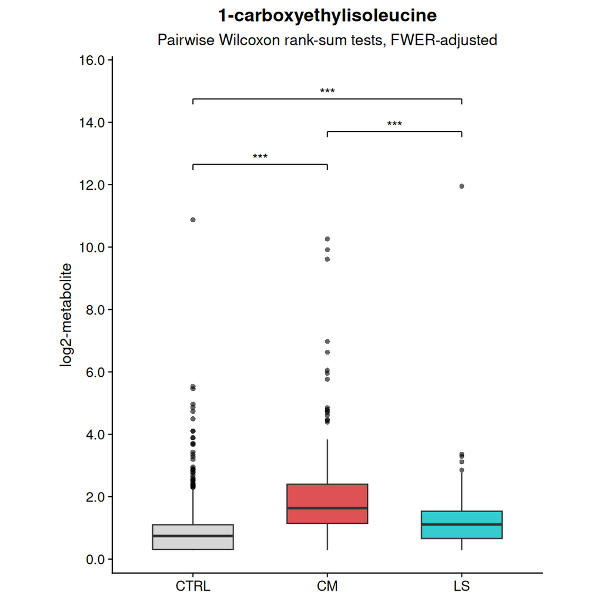

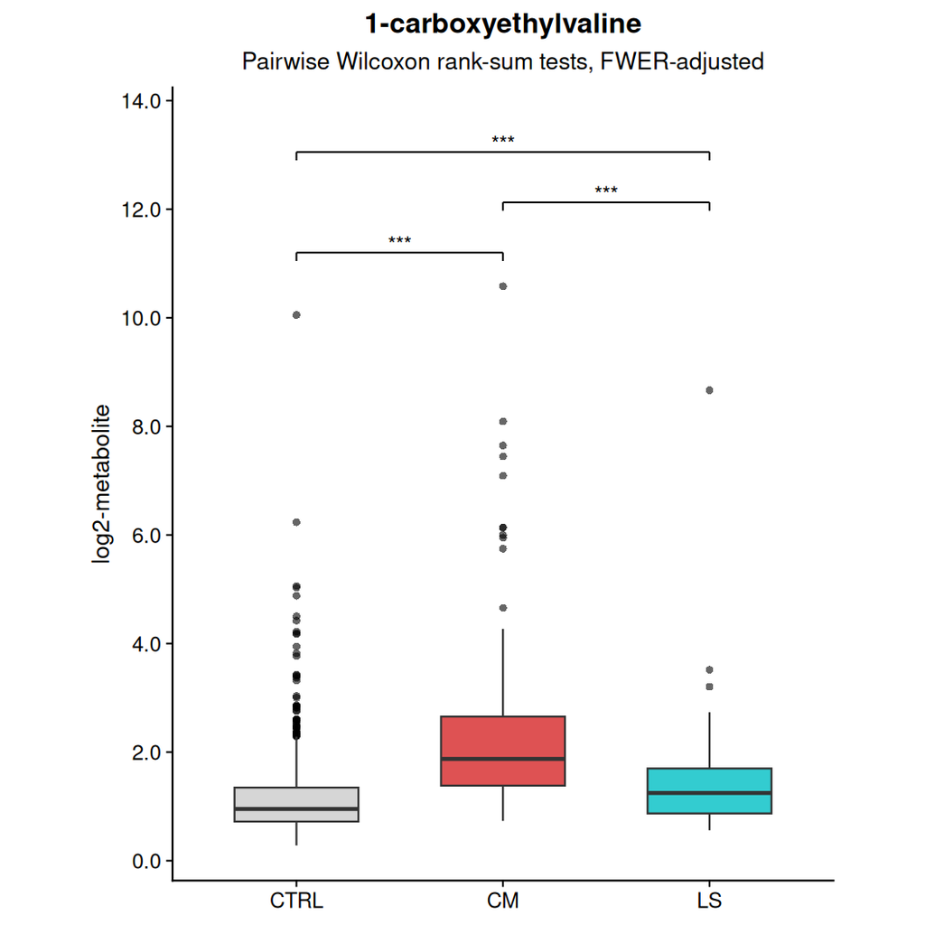

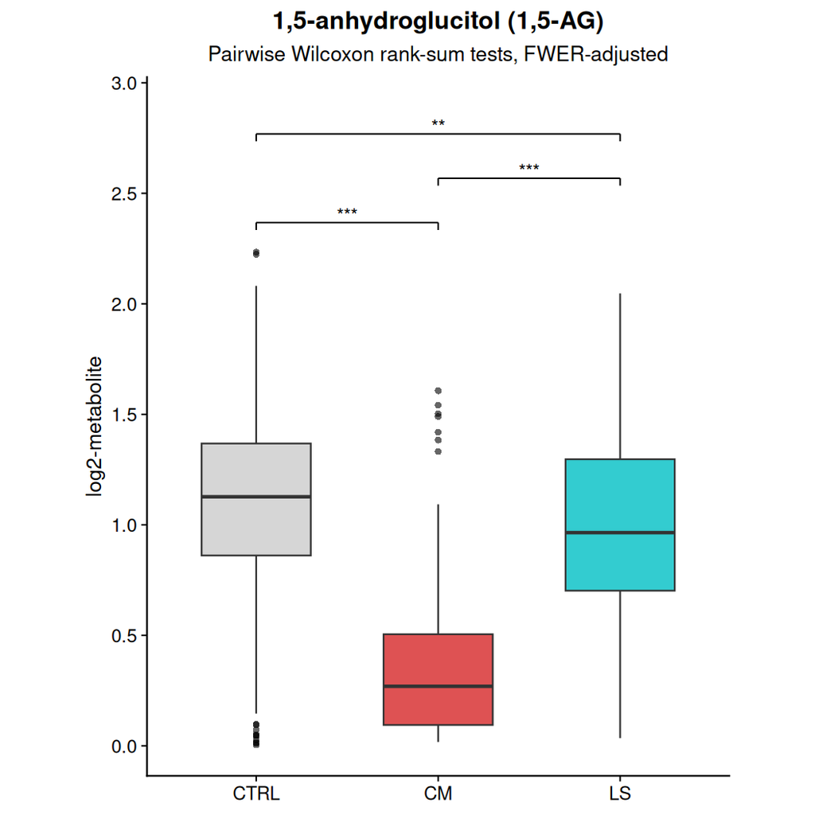

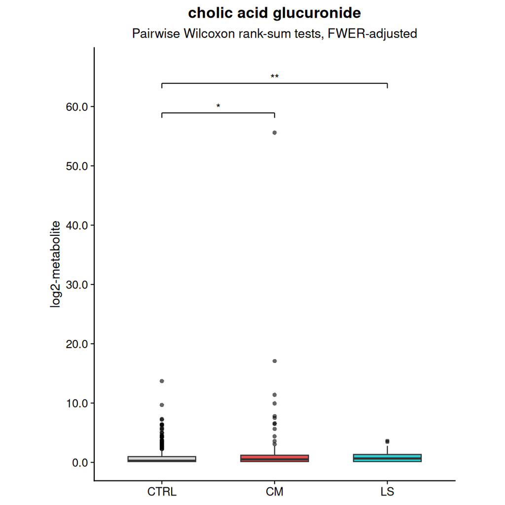

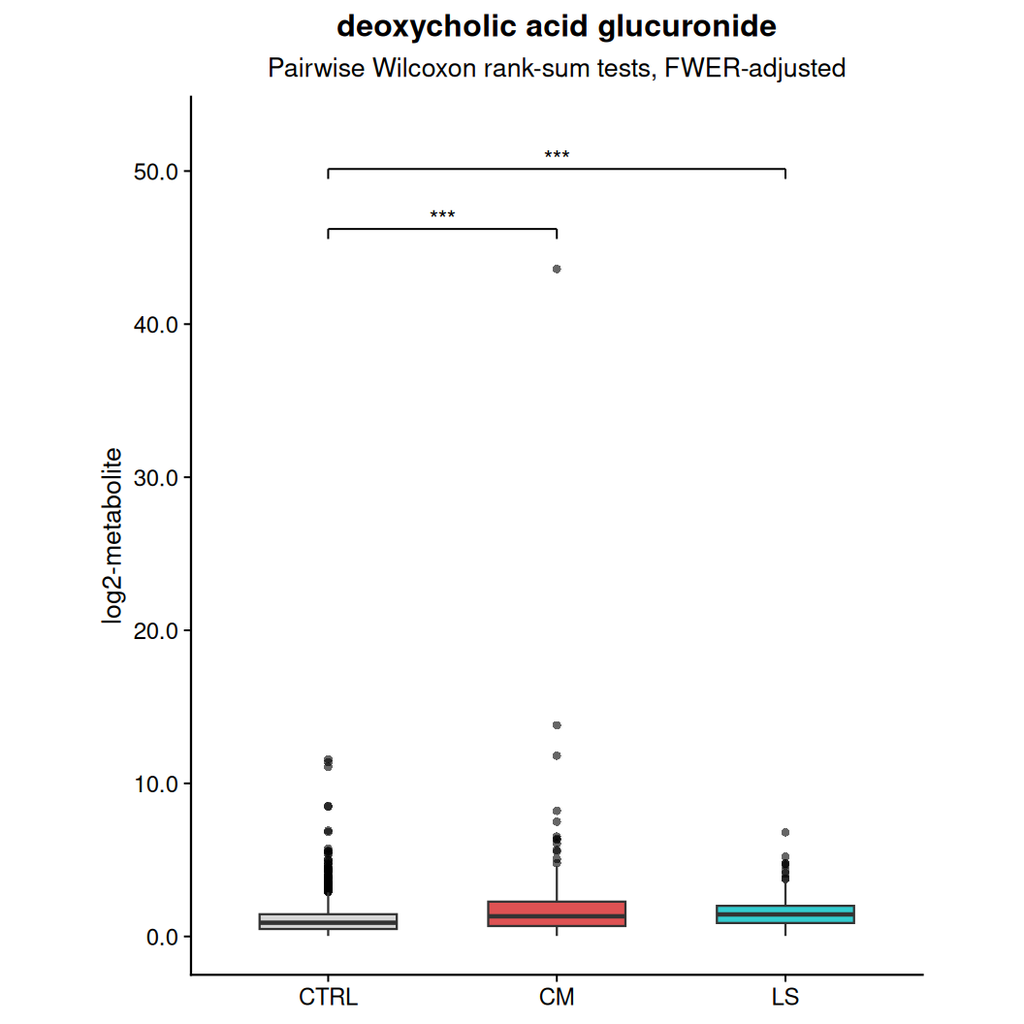

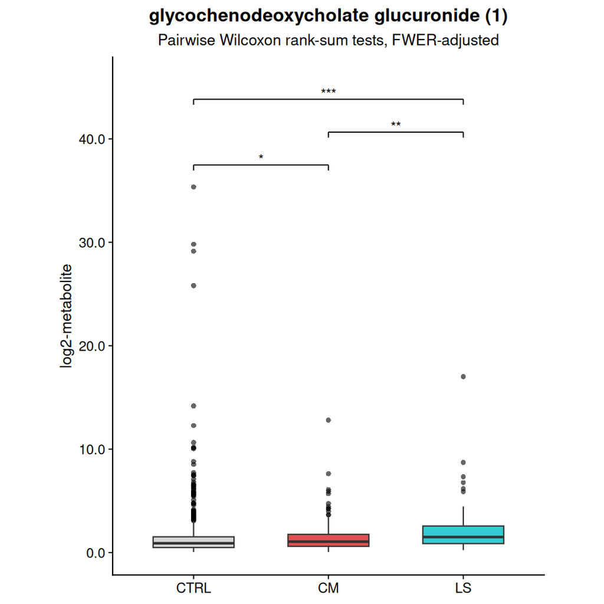

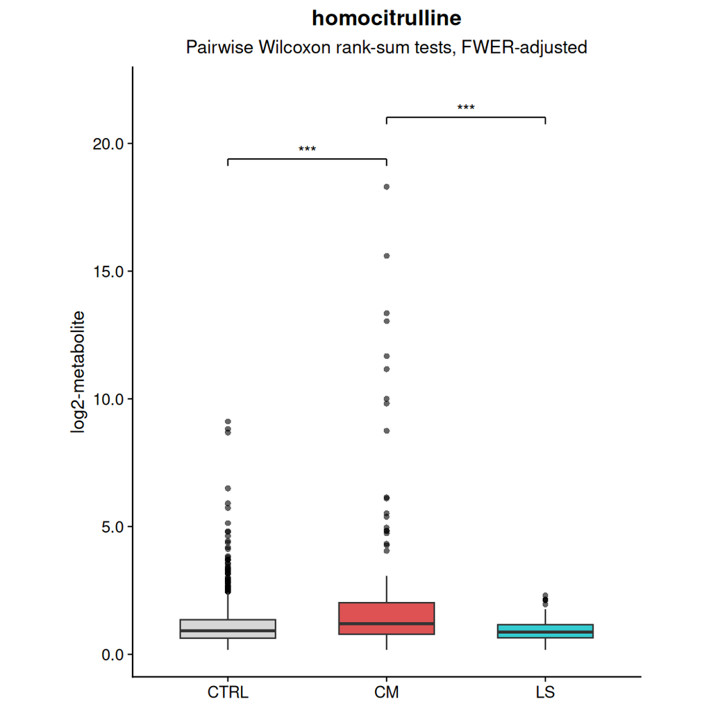

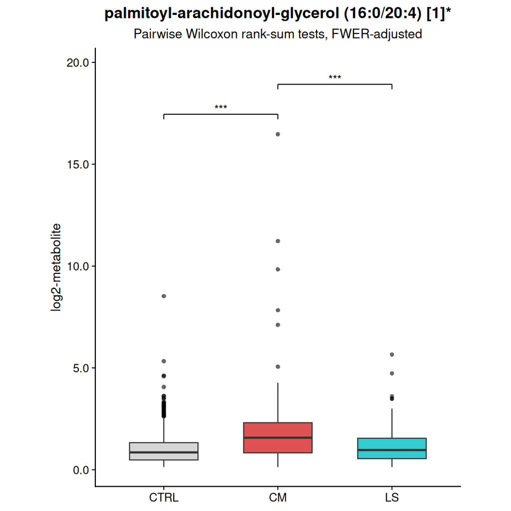

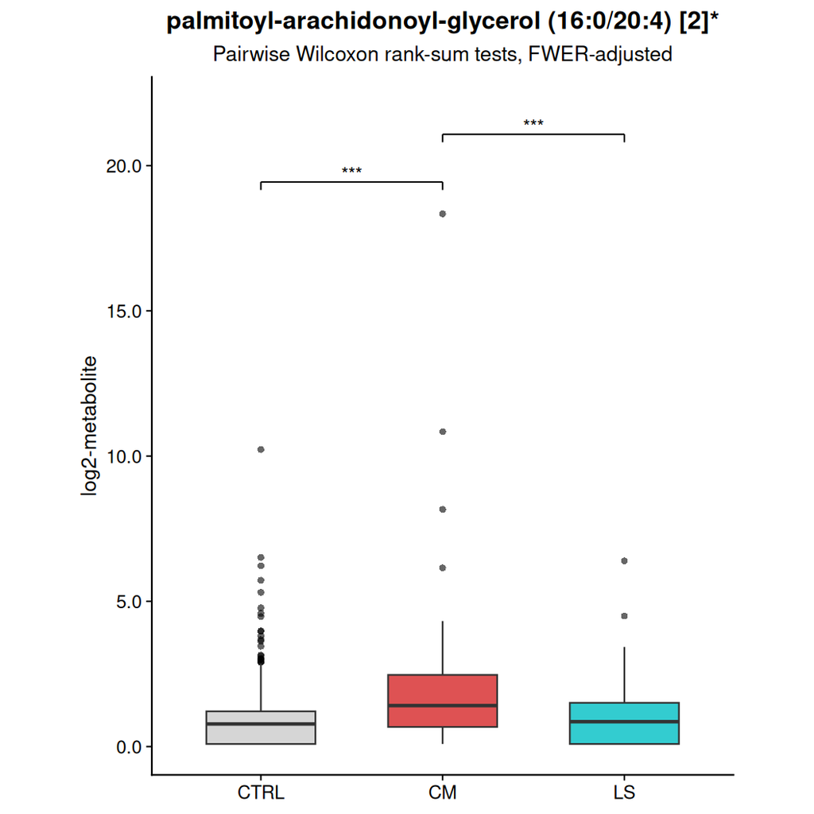

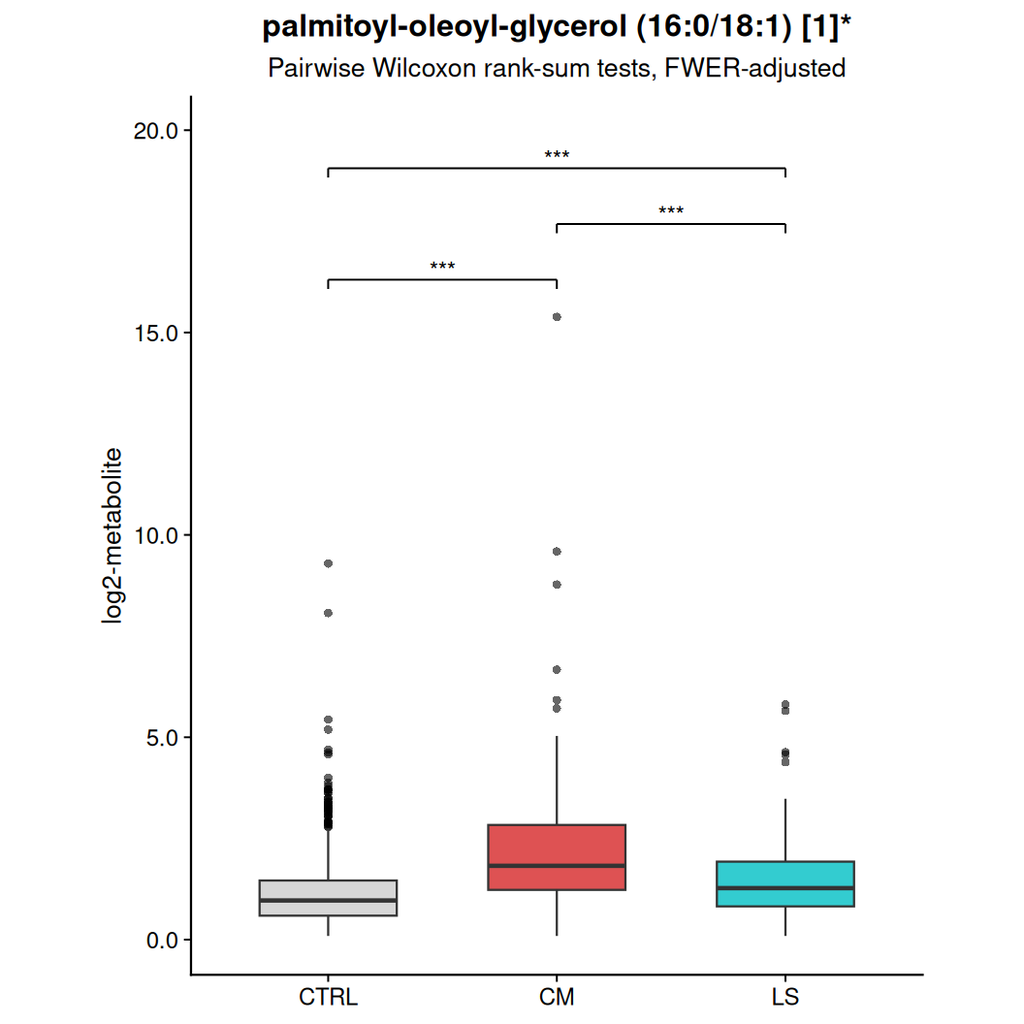

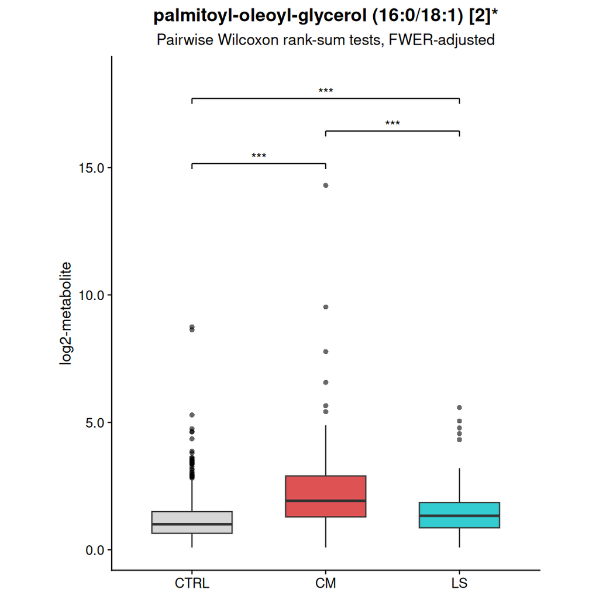

```r
mets  <- sort(unique(long$Metabolite))
plots <- lapply(mets, make_plot)

# pdf("metabolites_per_page.pdf", width = 5.5, height = 5.5)
for (p in plots) print(p)
```

```r
# dev.off()
```

# Part C — Validation in the whole biopsy cohort

## C1. Data prep

Helper functions for this section (`run_logistic`, `annotate_tbl`) live in `functions_logistic_wholecohort.R`, sourced above.

```r
### mash ~ metabolite + Age + sex_bin + BMI + ALT (+ AST)

plasma_whole <- t(plasma_sub)
pts          <- intersect(rownames(plasma_whole), rownames(clinical_sub))
plasma_whole <- plasma_whole[pts, , drop = FALSE]

covars <- data.frame(
  Age     = clinical_sub[pts, "AgeJourIntervention"],
  sex_bin = ifelse(as.character(clinical_sub[pts, "sexe"]) %in% female_codes, 0, 1),
  BMI     = clinical_sub[pts, "BMI"],
  ALT     = clinical_sub[pts, "TGPUL"],
  AST     = clinical_sub[pts, "AST"],
  mash    = clinical_sub[pts, "Mash"]
)

cat("Patients entering the whole-cohort models:", nrow(plasma_whole), "\n")
```

```
## Patients entering the whole-cohort models: 1321
```

## C2. Model 1 — adjusted for ALT

```r
res_alt <- run_logistic(plasma_whole, covars,
                        adjust = c("Age", "sex_bin", "BMI", "ALT"))
sig_alt <- annotate_tbl(res_alt, chemical_details)

cat("Significant, ALT-adjusted:", nrow(sig_alt), "\n")
```

```
## Significant, ALT-adjusted: 140
```

```r
cat("Total number of sub-pathways, ALT-adjusted:",
    length(unique(sig_alt$Sub_pathway)), "\n")
```

```
## Total number of sub-pathways, ALT-adjusted: 54
```

```r
datatable(sig_alt, caption = "MASH ~ metabolite + Age + sex + BMI + ALT",
          options = list(scrollX = TRUE))
```

|  | metabolite | Super_pathway | Sub_pathway | direction | beta | OR | 95% CI | p | FDR | n |
| --- | --- | --- | --- | --- | --- | --- | --- | --- | --- | --- |
| 1 | cysteine-glutathione disulfide | Amino Acid | Glutathione Metabolism | ↓ | -1.488 | 0.226 | 0.136-0.374 | 7.93e-09 | 6.94e-06 | 1241 |
| 2 | sphingomyelin (d18:2/24:2)* | Lipid | Sphingomyelins | ↓ | -0.767 | 0.464 | 0.355-0.608 | 2.62e-08 | 1.14e-05 | 1241 |
| 3 | gamma-glutamylvaline | Peptide | Gamma-glutamyl Amino Acid | ↑ | 0.578 | 1.782 | 1.445-2.198 | 6.64e-08 | 1.16e-05 | 1241 |
| 4 | sphingomyelin (d18:2/24:1, d18:1/24:2)* | Lipid | Sphingomyelins | ↓ | -0.672 | 0.511 | 0.400-0.651 | 6.23e-08 | 1.16e-05 | 1241 |
| 5 | lactosyl-N-behenoyl-sphingosine (d18:1/22:0)* | Lipid | Lactosylceramides (LCER) | ↑ | 0.5 | 1.649 | 1.375-1.976 | 6.45e-08 | 1.16e-05 | 1241 |
| 6 | 1-palmitoyl-2-arachidonoyl-GPE (16:0/20:4)* | Lipid | Phosphatidylethanolamine (PE) | ↑ | 0.464 | 1.59 | 1.338-1.890 | 1.45e-07 | 2.11e-05 | 1241 |
| 7 | N-acetylmethionine | Amino Acid | Methionine, Cysteine, SAM and Taurine Metabolism | ↓ | -0.794 | 0.452 | 0.335-0.610 | 2.18e-07 | 2.47e-05 | 1241 |
| 8 | N-stearoyl-sphingosine (d18:1/18:0)* | Lipid | Ceramides | ↑ | 0.463 | 1.589 | 1.333-1.893 | 2.26e-07 | 2.47e-05 | 1241 |
| 9 | glucose | Carbohydrate | Glycolysis, Gluconeogenesis, and Pyruvate Metabolism | ↑ | 0.44 | 1.553 | 1.308-1.843 | 4.85e-07 | 4.25e-05 | 1241 |
| 10 | 1,5-anhydroglucitol (1,5-AG) | Carbohydrate | Glycolysis, Gluconeogenesis, and Pyruvate Metabolism | ↓ | -0.578 | 0.561 | 0.448-0.702 | 4.51e-07 | 4.25e-05 | 1241 |

[output cut: 130 more lines]

```r
# Sub-pathways represented by more than one / exactly one metabolite
multi_alt      <- names(which(table(sig_alt$Sub_pathway) > 1))
single_alt     <- names(which(table(sig_alt$Sub_pathway) == 1))

sig_alt_multi <- sig_alt %>%
  filter(Sub_pathway %in% multi_alt) %>%
  arrange(Sub_pathway) %>%
  select(Sub_pathway, metabolite)

sig_alt_single <- sig_alt %>%
  filter(Sub_pathway %in% single_alt) %>%
  arrange(Sub_pathway) %>%
  select(Sub_pathway, metabolite)
```

## C3. Model 2 — adjusted for ALT + AST

```r
res_altast <- run_logistic(plasma_whole, covars,
                           adjust = c("Age", "sex_bin", "BMI", "ALT", "AST"))
sig_altast <- annotate_tbl(res_altast, chemical_details)

cat("Significant, ALT+AST-adjusted:", nrow(sig_altast), "\n")
```

```
## Significant, ALT+AST-adjusted: 103
```

```r
cat("Total number of sub-pathways, ALT+AST-adjusted:",
    length(unique(sig_altast$Sub_pathway)), "\n")
```

```
## Total number of sub-pathways, ALT+AST-adjusted: 40
```

```r
datatable(sig_altast, caption = "MASH ~ metabolite + Age + sex + BMI + ALT + AST",
          options = list(scrollX = TRUE))
```

|  | metabolite | Super_pathway | Sub_pathway | direction | beta | OR | 95% CI | p | FDR | n |
| --- | --- | --- | --- | --- | --- | --- | --- | --- | --- | --- |
| 1 | glucose | Carbohydrate | Glycolysis, Gluconeogenesis, and Pyruvate Metabolism | ↑ | 0.466 | 1.593 | 1.330-1.909 | 4.31e-07 | 0.000146 | 1241 |
| 2 | cysteine-glutathione disulfide | Amino Acid | Glutathione Metabolism | ↓ | -1.336 | 0.263 | 0.158-0.438 | 3.08e-07 | 0.000146 | 1241 |
| 3 | sphingomyelin (d18:2/24:1, d18:1/24:2)* | Lipid | Sphingomyelins | ↓ | -0.653 | 0.521 | 0.403-0.674 | 6.67e-07 | 0.000146 | 1241 |
| 4 | sphingomyelin (d18:2/24:2)* | Lipid | Sphingomyelins | ↓ | -0.723 | 0.485 | 0.365-0.645 | 6.22e-07 | 0.000146 | 1241 |
| 5 | 1,5-anhydroglucitol (1,5-AG) | Carbohydrate | Glycolysis, Gluconeogenesis, and Pyruvate Metabolism | ↓ | -0.58 | 0.56 | 0.443-0.708 | 1.33e-06 | 0.000166 | 1241 |
| 6 | gamma-glutamylvaline | Peptide | Gamma-glutamyl Amino Acid | ↑ | 0.532 | 1.702 | 1.374-2.107 | 1.09e-06 | 0.000166 | 1241 |
| 7 | 1-(1-enyl-palmitoyl)-2-oleoyl-GPC (P-16:0/18:1)* | Lipid | Plasmalogen | ↓ | -0.647 | 0.524 | 0.404-0.680 | 1.15e-06 | 0.000166 | 1241 |
| 8 | N-stearoyl-sphingosine (d18:1/18:0)* | Lipid | Ceramides | ↑ | 0.431 | 1.538 | 1.273-1.859 | 8.32e-06 | 0.000671 | 1241 |
| 9 | 1-palmitoyl-2-arachidonoyl-GPE (16:0/20:4)* | Lipid | Phosphatidylethanolamine (PE) | ↑ | 0.411 | 1.508 | 1.258-1.806 | 8.44e-06 | 0.000671 | 1241 |
| 10 | lactosyl-N-behenoyl-sphingosine (d18:1/22:0)* | Lipid | Lactosylceramides (LCER) | ↑ | 0.444 | 1.559 | 1.285-1.891 | 6.51e-06 | 0.000671 | 1241 |

[output cut: 93 more lines]

## C4. Metabolites robust to both models

```r
robust   <- intersect(sig_alt$metabolite, sig_altast$metabolite)
mash_ash <- sig_altast %>% filter(metabolite %in% robust)

cat("Significant in BOTH models:", length(robust), "\n")
```

```
## Significant in BOTH models: 101
```

```r
datatable(mash_ash,
          caption = "MASH-associated independent of ALT and AST",
          options = list(scrollX = TRUE))
```

|  | metabolite | Super_pathway | Sub_pathway | direction | beta | OR | 95% CI | p | FDR | n |
| --- | --- | --- | --- | --- | --- | --- | --- | --- | --- | --- |
| 1 | glucose | Carbohydrate | Glycolysis, Gluconeogenesis, and Pyruvate Metabolism | ↑ | 0.466 | 1.593 | 1.330-1.909 | 4.31e-07 | 0.000146 | 1241 |
| 2 | cysteine-glutathione disulfide | Amino Acid | Glutathione Metabolism | ↓ | -1.336 | 0.263 | 0.158-0.438 | 3.08e-07 | 0.000146 | 1241 |
| 3 | sphingomyelin (d18:2/24:1, d18:1/24:2)* | Lipid | Sphingomyelins | ↓ | -0.653 | 0.521 | 0.403-0.674 | 6.67e-07 | 0.000146 | 1241 |
| 4 | sphingomyelin (d18:2/24:2)* | Lipid | Sphingomyelins | ↓ | -0.723 | 0.485 | 0.365-0.645 | 6.22e-07 | 0.000146 | 1241 |
| 5 | 1,5-anhydroglucitol (1,5-AG) | Carbohydrate | Glycolysis, Gluconeogenesis, and Pyruvate Metabolism | ↓ | -0.58 | 0.56 | 0.443-0.708 | 1.33e-06 | 0.000166 | 1241 |
| 6 | gamma-glutamylvaline | Peptide | Gamma-glutamyl Amino Acid | ↑ | 0.532 | 1.702 | 1.374-2.107 | 1.09e-06 | 0.000166 | 1241 |
| 7 | 1-(1-enyl-palmitoyl)-2-oleoyl-GPC (P-16:0/18:1)* | Lipid | Plasmalogen | ↓ | -0.647 | 0.524 | 0.404-0.680 | 1.15e-06 | 0.000166 | 1241 |
| 8 | N-stearoyl-sphingosine (d18:1/18:0)* | Lipid | Ceramides | ↑ | 0.431 | 1.538 | 1.273-1.859 | 8.32e-06 | 0.000671 | 1241 |
| 9 | 1-palmitoyl-2-arachidonoyl-GPE (16:0/20:4)* | Lipid | Phosphatidylethanolamine (PE) | ↑ | 0.411 | 1.508 | 1.258-1.806 | 8.44e-06 | 0.000671 | 1241 |
| 10 | lactosyl-N-behenoyl-sphingosine (d18:1/22:0)* | Lipid | Lactosylceramides (LCER) | ↑ | 0.444 | 1.559 | 1.285-1.891 | 6.51e-06 | 0.000671 | 1241 |

[output cut: 91 more lines]

## C5. Singleton sub-pathways (ALT + AST model)

```r
single_altast <- names(which(table(sig_altast$Sub_pathway) == 1))

sig_altast_m1 <- sig_altast %>%
  filter(Sub_pathway %in% single_altast) %>%
  arrange(Sub_pathway) %>%
  transmute(
    Super_pathway,
    Sub_pathway,
    metabolite,
    direction,
    OR       = round(OR, 3),
    `95% CI` = `95% CI`,
    p        = signif(p, 3),
    FDR      = signif(FDR, 3)
  )

cat("Sub-pathways with 1 significant metabolite each:", nrow(sig_altast_m1), "\n")
```

```
## Sub-pathways with 1 significant metabolite each: 20
```

```r
datatable(
  sig_altast_m1,
  rownames = FALSE,
  options  = list(scrollX = TRUE),
  caption  = paste("Singleton sub-pathways: MASH-associated metabolites represented",
                   "by a single metabolite (adjusted for age, sex, BMI, ALT, AST)")
)
```

| Super_pathway | Sub_pathway | metabolite | direction | OR | 95% CI | p | FDR |
| --- | --- | --- | --- | --- | --- | --- | --- |
| Lipid | Androgenic Steroids | 16a-hydroxy DHEA 3-sulfate | ↑ | 1.307 | 1.088-1.571 | 0.00427 | 0.0399 |
| Cofactors and Vitamins | Ascorbate and Aldarate Metabolism | oxalate (ethanedioate) | ↓ | 0.723 | 0.577-0.906 | 0.00475 | 0.0424 |
| Lipid | Carnitine Metabolism | deoxycarnitine | ↓ | 0.618 | 0.486-0.786 | 8.6e-05 | 0.00358 |
| Lipid | Dihydroceramides | N-stearoyl-sphinganine (d18:0/18:0)* | ↑ | 1.321 | 1.094-1.595 | 0.00375 | 0.0357 |
| Peptide | Dipeptide | isoleucylglycine | ↓ | 0.659 | 0.498-0.872 | 0.00349 | 0.0348 |
| Lipid | Fatty Acid Metabolism (also BCAA Metabolism) | butyrylglycine | ↑ | 1.409 | 1.178-1.687 | 0.00018 | 0.00521 |
| Lipid | Fatty Acid, Dicarboxylate | hydroxy-CMPF* | ↓ | 0.518 | 0.355-0.755 | 0.000617 | 0.0128 |
| Amino Acid | Glutamate Metabolism | glutamate | ↑ | 1.425 | 1.160-1.750 | 0.000724 | 0.0141 |
| Amino Acid | Glutathione Metabolism | cysteine-glutathione disulfide | ↓ | 0.263 | 0.158-0.438 | 3.08e-07 | 0.000146 |
| Carbohydrate | Glycogen Metabolism | maltose | ↑ | 1.32 | 1.122-1.552 | 0.000814 | 0.0148 |

[output cut: 10 more lines]

## C6. Model diagnostics (optional)

Calibration (Hosmer-Lemeshow) and discrimination (AUC) per metabolite. Disabled by default because it refits several hundred models; set `eval=TRUE` on these chunks to run them.

```r
# Refit each significant metabolite in a given model and return HL p + AUC
fit_diagnostics <- function(sig_tbl, adjust, plasma_mat, covars) {
  form <- as.formula(paste("mash ~", paste(c("metabolite", adjust), collapse = " + ")))
  out <- lapply(sig_tbl$metabolite, function(met) {
    df <- data.frame(metabolite = as.numeric(plasma_mat[, met]), covars) |> na.omit()
    df$metabolite <- as.numeric(scale(df$metabolite))
    fit  <- suppressWarnings(glm(form, data = df, family = binomial()))
    ynum <- as.numeric(as.character(df$mash))
    prob <- fitted(fit)
    data.frame(
      metabolite = met,
      AUC  = round(as.numeric(auc(roc(ynum, prob, direction = "<", quiet = TRUE))), 3),
      HL_p = round(tryCatch(hoslem.test(ynum, prob, g = 10)$p.value,
                            error = function(e) NA), 3)
    )
  })
  bind_rows(out)
}

diag_alt    <- fit_diagnostics(sig_alt,    c("Age", "sex_bin", "BMI", "ALT"),
                               plasma_whole, covars)
diag_altast <- fit_diagnostics(sig_altast, c("Age", "sex_bin", "BMI", "ALT", "AST"),
                               plasma_whole, covars)

cat("== Model 1 (ALT) fit diagnostics ==\n")
cat("Mean AUC:", round(mean(diag_alt$AUC), 3),
    "| calibrated models (HL p > 0.05):", sum(diag_alt$HL_p > 0.05, na.rm = TRUE),
    "of", nrow(diag_alt), "\n")
datatable(diag_alt, caption = "Model 1 (ALT): AUC + Hosmer-Lemeshow per metabolite")

cat("\n== Model 2 (ALT+AST) fit diagnostics ==\n")
cat("Mean AUC:", round(mean(diag_altast$AUC), 3),
    "| calibrated models (HL p > 0.05):", sum(diag_altast$HL_p > 0.05, na.rm = TRUE),
    "of", nrow(diag_altast), "\n")
datatable(diag_altast, caption = "Model 2 (ALT+AST): AUC + Hosmer-Lemeshow per metabolite")
```

```r
# Did adding AST change anything?
alt_only    <- setdiff(sig_alt$metabolite,    sig_altast$metabolite)  # dropped when AST added
altast_only <- setdiff(sig_altast$metabolite, sig_alt$metabolite)     # emerged when AST added

cat("Robust to both        :", length(robust), "\n")
cat("ALT only (lost w/ AST):", length(alt_only), "\n")
cat("ALT+AST only (gained) :", length(altast_only), "\n\n")

comparison <- full_join(
  res_alt    %>% select(metabolite, OR_alt    = OR, FDR_alt    = FDR),
  res_altast %>% select(metabolite, OR_altast = OR, FDR_altast = FDR),
  by = "metabolite"
) %>%
  filter(FDR_alt <= 0.05 | FDR_altast <= 0.05) %>%
  mutate(status = case_when(
    FDR_alt <= 0.05 & FDR_altast <= 0.05 ~ "both",
    FDR_alt <= 0.05                      ~ "ALT only",
    TRUE                                 ~ "ALT+AST only"
  )) %>%
  transmute(metabolite, status,
            OR_alt    = round(OR_alt, 3),    FDR_alt    = signif(FDR_alt, 3),
            OR_altast = round(OR_altast, 3), FDR_altast = signif(FDR_altast, 3)) %>%
  arrange(status, FDR_altast)

datatable(comparison,
          caption = "Model 1 (ALT) vs Model 2 (ALT+AST): per-metabolite comparison")
```

```r
# Metabolites whose model was NOT well calibrated (HL p < 0.05)
poorly_cal_alt    <- diag_alt$metabolite[!is.na(diag_alt$HL_p)       & diag_alt$HL_p       < 0.05]
poorly_cal_altast <- diag_altast$metabolite[!is.na(diag_altast$HL_p) & diag_altast$HL_p    < 0.05]

cat("== Poorly calibrated (HL p < 0.05) ==\n")
cat("Model 1 (ALT):", length(poorly_cal_alt), "metabolites\n")
print(poorly_cal_alt)
cat("\nModel 2 (ALT+AST):", length(poorly_cal_altast), "metabolites\n")
print(poorly_cal_altast)

datatable(
  diag_altast %>% filter(metabolite %in% poorly_cal_alt) %>% arrange(HL_p),
  caption = "Model 1 metabolites failing calibration (HL p < 0.05)"
)

datatable(
  diag_altast %>% filter(metabolite %in% poorly_cal_altast) %>% arrange(HL_p),
  caption = "Model 2 metabolites failing calibration (HL p < 0.05)"
)
```

```r
# Visual calibration check for one poorly calibrated metabolite
met <- poorly_cal_alt[15]
met

df  <- data.frame(metabolite = scale(as.numeric(plasma_whole[, met])), covars) |> na.omit()
fit <- glm(mash ~ metabolite + Age + sex_bin + BMI + ALT, df, family = binomial())
df$pred <- fitted(fit)
df$obs  <- as.numeric(as.character(df$mash))

df %>%
  mutate(bin = ntile(pred, 10)) %>%
  group_by(bin) %>%
  summarise(pred = mean(pred), obs = mean(obs)) %>%
  {
    plot(.$pred, .$obs, xlim = c(0, 1), ylim = c(0, 1))
    abline(0, 1, lty = 2)
  }
```

## C7. Pathway scores — coherent sub-pathways

Coherent = at least two validated metabolites moving in the same direction.

For each such sub-pathway:

1. take its validated metabolites;
2. Z-score each across patients;
3. flip metabolites with a negative beta, so higher = MASH-associated;
4. score = unweighted mean of the aligned Z-scores (per patient);
5. regress the score on MASH, adjusted for age / sex / BMI / ALT / AST.

Pathways are then ranked by the association of their score with MASH. Helpers (`build_score`, `rank_pathways`) live in `functions_pathway_scores.R`.

```r
coherent <- sig_altast %>%
  group_by(Sub_pathway) %>%
  summarise(
    n    = n(),
    n_up = sum(direction == "\u2191"),
    n_dn = sum(direction == "\u2193"),
    .groups = "drop"
  ) %>%
  filter(n_up >= 2 | n_dn >= 2)     # at least 2 in the same direction

cat("Sub-pathways to score:", nrow(coherent), "\n")
```

```
## Sub-pathways to score: 18
```

```r
print(coherent$Sub_pathway)
```

```
##  [1] "Ceramides"
##  [2] "Diacylglycerol"
##  [3] "Fatty Acid Metabolism (Acyl Choline)"
##  [4] "Fructose, Mannose and Galactose Metabolism"
##  [5] "Gamma-glutamyl Amino Acid"
##  [6] "Glycolysis, Gluconeogenesis, and Pyruvate Metabolism"
##  [7] "Histidine Metabolism"
##  [8] "Leucine, Isoleucine and Valine Metabolism"
##  [9] "Long Chain Polyunsaturated Fatty Acid (n3 and n6)"
## [10] "Lysophospholipid"
## [11] "Lysoplasmalogen"
## [12] "Methionine, Cysteine, SAM and Taurine Metabolism"
## [13] "Phosphatidylcholine (PC)"
## [14] "Phosphatidylethanolamine (PE)"
## [15] "Plasmalogen"
## [16] "Progestin Steroids"
## [17] "Sphingomyelins"
## [18] "TCA Cycle"
```

```r
# Score using all metabolites in the sub-pathway (aligned by beta)
score_mat <- sapply(coherent$Sub_pathway, build_score)
rownames(score_mat) <- rownames(plasma_whole)

# Regress each score on MASH (adjusted), collect stats
pathway_ranked <- rank_pathways(score_mat, covars) %>%
  arrange(pvalue) %>%
  mutate(rank = row_number())

datatable(
  pathway_ranked %>% transmute(
    rank,
    Sub_pathway, n_metabolites,
    OR       = round(OR, 3),
    `95% CI` = sprintf("%.3f-%.3f", CI_low, CI_high),
    p        = signif(pvalue, 3),
    `p (Holm)` = signif(p_holm, 3)
  ),
  rownames = FALSE,
  options  = list(scrollX = TRUE),
  caption  = paste("Coherent sub-pathway scores ranked by association with MASH",
                   "(adjusted for age, sex, BMI, ALT, AST)")
)
```

| rank | Sub_pathway | n_metabolites | OR | 95% CI | p | p (Holm) |
| --- | --- | --- | --- | --- | --- | --- |
| 1 | Methionine, Cysteine, SAM and Taurine Metabolism | 3 | 3.227 | 2.188-4.760 | 3.45e-09 | 6.2e-08 |
| 2 | Glycolysis, Gluconeogenesis, and Pyruvate Metabolism | 3 | 2.14 | 1.652-2.773 | 8.58e-09 | 1.46e-07 |
| 3 | Leucine, Isoleucine and Valine Metabolism | 7 | 2.041 | 1.543-2.698 | 5.55e-07 | 8.88e-06 |
| 4 | Plasmalogen | 4 | 2.02 | 1.517-2.691 | 1.51e-06 | 2.27e-05 |
| 5 | Sphingomyelins | 12 | 2.228 | 1.600-3.103 | 2.15e-06 | 3.01e-05 |
| 6 | Ceramides | 4 | 1.82 | 1.416-2.339 | 2.93e-06 | 3.81e-05 |
| 7 | Gamma-glutamyl Amino Acid | 3 | 1.586 | 1.274-1.973 | 3.56e-05 | 0.000427 |
| 8 | Phosphatidylethanolamine (PE) | 8 | 1.502 | 1.231-1.833 | 6.18e-05 | 0.000679 |
| 9 | TCA Cycle | 2 | 1.676 | 1.299-2.162 | 7.07e-05 | 0.000707 |
| 10 | Histidine Metabolism | 2 | 1.857 | 1.366-2.524 | 7.8e-05 | 0.000707 |

[output cut: 8 more lines]

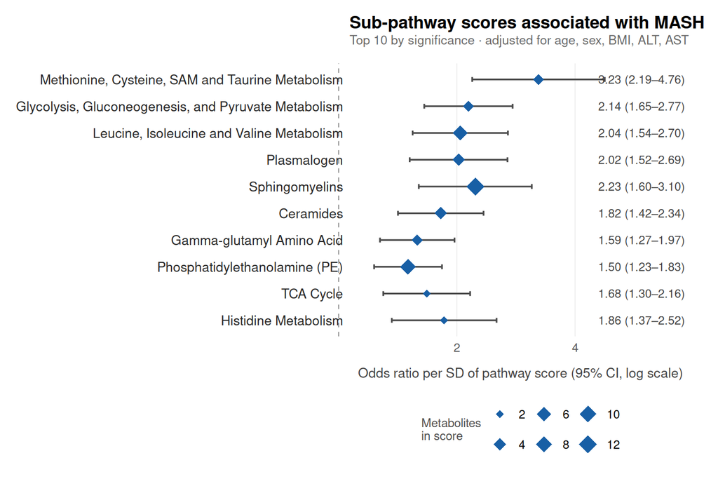

```r
top10 <- pathway_ranked %>%
  arrange(p_holm) %>%
  slice_head(n = 10) %>%
  mutate(
    Sub_pathway = factor(Sub_pathway, levels = rev(Sub_pathway)),  # rank order top -> bottom
    label       = sprintf("%.2f (%.2f\u2013%.2f)", OR, CI_low, CI_high)
  )

# Headroom on the right for the OR labels (log scale)
x_max <- max(top10$CI_high) * 1.6

p_forest <- ggplot(top10, aes(x = OR, y = Sub_pathway)) +
  geom_vline(xintercept = 1, linetype = "dashed", colour = "grey60", linewidth = 0.4) +
  geom_errorbarh(aes(xmin = CI_low, xmax = CI_high),
                 height = 0.18, colour = "#4a4a4a", linewidth = 0.6) +
  geom_point(aes(size = n_metabolites), colour = "#185FA5", shape = 18) +
  geom_text(aes(x = x_max, label = label), hjust = 1, size = 3.1, colour = "grey25") +
  scale_x_log10(
    breaks = c(0.5, 1, 2, 4, 8),
    expand = expansion(mult = c(0.02, 0.02))
  ) +
  scale_size_continuous(range = c(2.5, 6), name = "Metabolites\nin score") +
  coord_cartesian(xlim = c(min(top10$CI_low) * 0.9, x_max), clip = "off") +
  labs(
    x        = "Odds ratio per SD of pathway score (95% CI, log scale)",
    y        = NULL,
    title    = "Sub-pathway scores associated with MASH",
    subtitle = "Top 10 by significance \u00b7 adjusted for age, sex, BMI, ALT, AST"
  ) +
  theme_minimal(base_size = 11, base_family = "Helvetica") +
  theme(
    plot.title    = element_text(face = "bold", size = 13, margin = ggplot2::margin(b = 2)),
    plot.subtitle = element_text(colour = "grey40", size = 9.5, margin = ggplot2::margin(b = 12)),
    axis.title.x  = element_text(size = 10, margin = ggplot2::margin(t = 10), colour = "grey25"),
    axis.text.y   = element_text(size = 10, colour = "grey15"),
    axis.text.x   = element_text(size = 9,  colour = "grey35"),
    panel.grid.major.y = element_blank(),
    panel.grid.minor   = element_blank(),
    panel.grid.major.x = element_line(colour = "grey92", linewidth = 0.3),
    legend.position = "bottom",
    legend.title    = element_text(size = 9, colour = "grey30"),
    legend.text     = element_text(size = 9),
    plot.margin     = ggplot2::margin(12, 20, 12, 12)
  )

p_forest
```

# Part D — Liver transcriptomics (whole cohort)

## D1. Align transcriptomic data to the MASH cohort

```r
# All patients with non-missing MASH status in clinical_data
# (no plasma / ALT restriction here - this is the full transcriptomic cohort)
common_samples_tx <- intersect(rownames(clinical_data), colnames(transcript_data))

clinical_tx <- clinical_data[common_samples_tx, , drop = FALSE]
tx_sub      <- transcript_data[, common_samples_tx, drop = FALSE]  # genes x samples

cat("Common (transcriptomic) patients:", length(common_samples_tx), "\n")
```

```
## Common (transcriptomic) patients: 908
```

```r
work_tx <- data.frame(
  patient = common_samples_tx,
  mash    = clinical_tx$Mash,
  sex     = clinical_tx$sexe,
  ALT     = clinical_tx$TGPUL,
  AST     = clinical_tx$AST,
  Age     = clinical_tx$AgeJourIntervention,
  BMI     = clinical_tx$BMI,
  stringsAsFactors = FALSE
) %>%
  filter(!is.na(mash), !is.na(sex), !is.na(ALT), !is.na(AST),
         !is.na(Age), !is.na(BMI)) %>%
  mutate(
    sex_label = ifelse(as.character(sex) %in% female_codes, "Female", "Male"),
    mash_lab  = factor(ifelse(mash == 1, "MASH", "noMASH"),
                       levels = c("noMASH", "MASH"))
  )

cat("Patients entering limma (complete covariates):", nrow(work_tx), "\n")
```

```
## Patients entering limma (complete covariates): 831
```

```r
print(table(work_tx$mash_lab, useNA = "ifany"))
```

```
##
## noMASH   MASH
##    755     76
```

## D2. Differential expression — limma

MASH vs no-MASH, adjusted for Age, sex, BMI, ALT and AST.

```r
mt <- work_tx
rownames(mt) <- mt$patient
mt$grp     <- factor(mt$mash_lab, levels = c("noMASH", "MASH"))
mt$sex_bin <- ifelse(mt$sex_label == "Female", 0, 1)

cat("Group sizes entering limma:\n")
```

```
## Group sizes entering limma:
```

```r
print(table(mt$grp, useNA = "ifany"))
```

```
##
## noMASH   MASH
##    755     76
```

```r
xt <- as.matrix(tx_sub[, rownames(mt), drop = FALSE])

design_tx <- model.matrix(~ -1 + grp + Age + sex_bin + BMI + ALT + AST, data = mt)
fit_tx    <- lmFit(xt, design_tx)
comp_tx   <- comparisonsLimmaFct(fit_tx, "grpMASH - grpnoMASH", design_tx, nrow(xt))
res_tx    <- printResultsLimmaFct(comp_tx, topPrintHist = FALSE, topPrintVolc = FALSE)
```

```
## There are 468 differentially expressed features considering threshold 0.05 on adjusted P-values, and 397 when adding the threshold 0.26 on absolute value of log2 Fold Change.
```

```r
sig_tx <- rownames(
  res_tx$results[
    !is.na(res_tx$results$adj.P.Val) &
      res_tx$results$adj.P.Val < 0.05, , drop = FALSE]
)
cat("MASH vs noMASH, whole cohort, adjusted for Age/sex/BMI/ALT/AST —",
    "significant (FDR < 0.05):", length(sig_tx), "\n")
```

[output not shown]

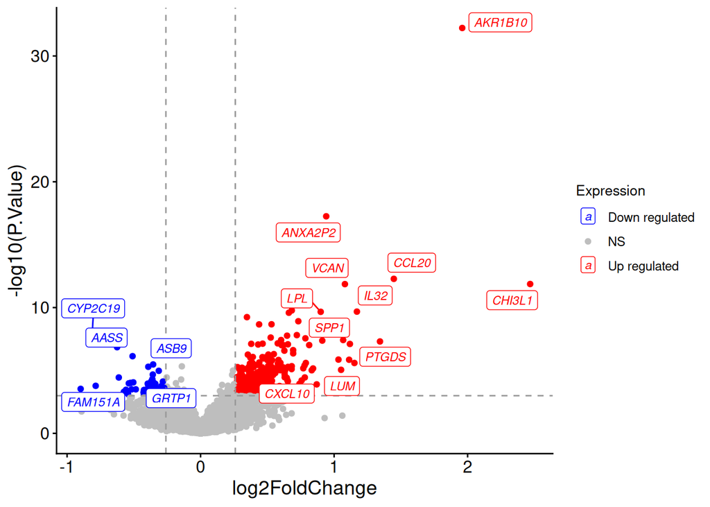

```r
res_tx$volcano
```

## D3. Gene set resources (built once)

The SYMBOL-to-ENTREZ map and the MSigDB GO:BP table are built once here and reused in both Part D and Part E.

```r
# SYMBOL -> ENTREZID
symbEntrezid <- bitr(rownames(transcript_data),
                     fromType = "SYMBOL",
                     toType   = "ENTREZID",
                     OrgDb    = "org.Hs.eg.db")
symbEntrezid <- symbEntrezid[order(symbEntrezid$SYMBOL), ]
symbEntrezid <- symbEntrezid[!duplicated(symbEntrezid$SYMBOL), ]

nMatch <- nrow(symbEntrezid)
pMatch <- round(nMatch / nrow(transcript_data) * 100, 2)
cat("Genes matched to ENTREZ identifiers:", nMatch, "of",
    nrow(transcript_data), "(", pMatch, "%)\n")
```

```
## Genes matched to ENTREZ identifiers: 20693 of 22953 ( 90.15 %)
```

```r
# MSigDB GO:BP - works with both the old (category/subcategory) and the
# new (collection/subcollection) msigdbr argument names.
gobp_human <- tryCatch(
  msigdbr(species = "Homo sapiens", category = "C5", subcategory = "BP"),
  error = function(e)
    msigdbr(species = "Homo sapiens", collection = "C5", subcollection = "GO:BP")
)
gobp_human <- gobp_human[, c("gs_name", "entrez_gene")]
gobp_human$gs_name <- str_to_lower(substr(gobp_human$gs_name, 6, nchar(gobp_human$gs_name)))
```

## D4. Pathway enrichment analysis (whole cohort)

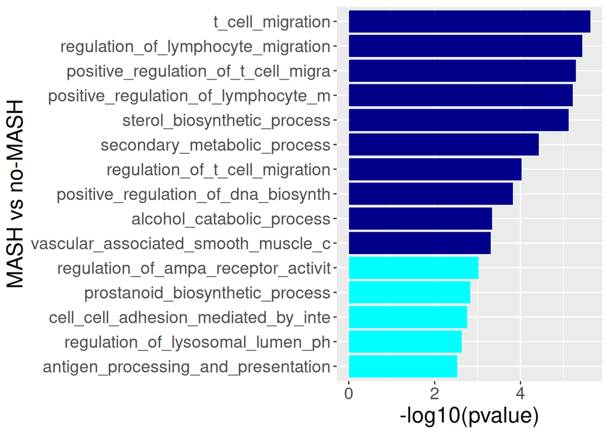

```r
gobp_tx_mash <- enrichMsigdbFct(results      = comp_tx$mstat,
                                dataBase     = gobp_human,
                                symbEntrezid = symbEntrezid)

printResultsEnrchHistFct(enrchResults = gobp_tx_mash$resultHist,
                         xlab = "MASH vs no-MASH")
```

```r
rownames(gobp_tx_mash$resultEnrich) <- NULL
sig_pathway <- gobp_tx_mash$resultEnrich[gobp_tx_mash$resultEnrich$p.adjust <= 0.05, ]

datatable(
  sig_pathway[, c("ID", "setSize", "NES", "rank", "p.adjust",
                  "n_leading", "leading_edge")],
  options = list(scrollX = TRUE),
  caption = "GO-BP enrichment, whole cohort (FDR <= 0.05)"
) %>%
  formatRound(columns = "NES", digits = 6) %>%
  formatSignif(columns = "p.adjust", digits = 6)
```

|  | ID | setSize | NES | rank | p.adjust | n_leading | leading_edge |
| --- | --- | --- | --- | --- | --- | --- | --- |
| 1 | positive_regulation_of_t_cell_migration | 36 | 1.808935601939429 | 3279 | 0.002339650923798266 | 14 | CCL20, CXCL10, CCR2, PYCARD, WNK1, ITGA4, ADAM10, TNFSF14, SPN, CCL21, ABL1, AIF1, ASCL2, TNFRSF14 |
| 2 | positive_regulation_of_lymphocyte_migration | 43 | 1.746972316155534 | 3493 | 0.002377871093133194 | 16 | CCL20, CXCL10, CCR2, PYCARD, WNK1, ITGA4, ADAM10, TNFSF14, SPN, JAM2, CCL21, ABL1, AIF1, ASCL2, TNFRSF14, NEDD9 |
| 3 | regulation_of_lymphocyte_migration | 67 | 1.659067296065862 | 3723 | 0.002221127318273176 | 25 | CCL20, MSN, CXCL10, CCL2, CCR2, PYCARD, GCSAML, WNK1, ITGA4, ADAM10, TNFSF14, ECM1, CRKL, SPN, JAM2, CCL21, ABL1, AIF1, RIPOR2, STK10, ASCL2, TNFRSF14, NEDD9, SPNS2, PADI2 |
| 4 | t_cell_migration | 73 | 1.632003407412665 | 3581 | 0.002221127318273176 | 26 | CCL20, MSN, CXCL10, CCL2, CCR2, PYCARD, CXCL16, WNK1, ICAM1, ITGA4, GPR183, ADAM10, TNFSF14, PIK3CD, ECM1, S1PR1, CRKL, SPN, SLC12A2, CCL21, ABL1, AIF1, RIPOR2, ASCL2, TNFRSF14, SPNS2 |
| 5 | regulation_of_t_cell_migration | 49 | 1.630620472367116 | 3581 | 0.01885130613948067 | 18 | CCL20, CXCL10, CCR2, PYCARD, WNK1, ITGA4, ADAM10, TNFSF14, ECM1, CRKL, SPN, CCL21, ABL1, AIF1, RIPOR2, ASCL2, TNFRSF14, SPNS2 |
| 6 | alcohol_catabolic_process | 36 | 1.614678875605468 | 6847 | 0.04584580520347382 | 24 | AKR1B10, AKR1C3, CYP7A1, APOE, SULT1E1, SULT1C4, ALDH1B1, SCARB1, SRD5A3, SULT1A1, SULT1A2, GPD2, ALDH3B2, AKR1D1, CYP39A1, SORD, SULT2A1, SULT1B1, ALDH2, ACSS1, CYP27A1, CYP46A1, ADH4, ACSS2 |
| 7 | sterol_biosynthetic_process | 71 | 1.609483410173338 | 1643 | 0.002539351746754846 | 21 | ACLY, HMGCS1, SREBF2, ERG28, NPC1L1, CYP51A1, NSDHL, CES1, MVD, SC5D, CYP7A1, FDFT1, MSMO1, HSD17B7, CYB5R3, PRKAA2, DHCR7, APOE, LSS, MIR98, MIR182 |
| 8 | positive_regulation_of_dna_biosynthetic_process | 44 | 1.609224607544615 | 2985 | 0.02273370575445156 | 15 | HNRNPA1, HGF, PDGFRB, HSP90AA1, RFC4, CCT3, SMOC2, CCT4, CCT6A, DKC1, CCT5, CCT7, ATR, PARN, TCP1 |
| 10 | secondary_metabolic_process | 53 | 1.603448232091628 | 3595 | 0.01033435623431303 | 22 | AKR1B10, AKR1C2, CTNS, AKR1C3, CYP2D6, AKR1A1, MGRN1, SLC45A2, RAPGEF2, AKR1C4, FMO1, SULT1C4, PMEL, PRKCE, ARL1, AKR7A2, OCA2, AKR7A3, CYP2A7, SLC7A11, CYP3A5, NFE2L2 |
| 14 | vascular_associated_smooth_muscle_cell_migration | 42 | 1.570907076167809 | 4528 | 0.04639563410973413 | 22 | MAP3K7, SSH1, MIR1298, DOCK7, FGF9, PTPN1, XBP1, GNA12, MIR182, MIR499A, MIR448, ADAMTS1, MIR665, IGFBP5, MIR146A, ADIPOQ, DDIT3, MIR135B, MIR362, NFE2L2, MIR21, MIR26A1 |

[output cut: 30 more lines]

# Part E — Liver transcriptomics, normal ALT

## E1. Restrict to normal-ALT patients

```r
common_samples_tx_nrm <- intersect(rownames(clinical_data), colnames(transcript_data))

clinical_tx_nrm <- clinical_data[common_samples_tx_nrm, , drop = FALSE]
tx_sub_nrm      <- transcript_data[, common_samples_tx_nrm, drop = FALSE]

cat("Common transcriptomic patients:", length(common_samples_tx_nrm), "\n")
```

```
## Common transcriptomic patients: 908
```

```r
work_tx_normal_alt <- data.frame(
  patient = common_samples_tx_nrm,
  mash    = clinical_tx_nrm$Mash,
  sex     = clinical_tx_nrm$sexe,
  ALT     = clinical_tx_nrm$TGPUL,
  AST     = clinical_tx_nrm$AST,
  Age     = clinical_tx_nrm$AgeJourIntervention,
  BMI     = clinical_tx_nrm$BMI,
  stringsAsFactors = FALSE
) %>%
  filter(!is.na(mash), !is.na(ALT)) %>%
  mutate(
    sex_label = case_when(
      as.character(sex) %in% female_codes ~ "Female",
      as.character(sex) %in% male_codes   ~ "Male",
      TRUE ~ NA_character_
    ),
    alt_normal = ALT >= alt_lo & ALT <= alt_hi,
    mash_lab   = factor(ifelse(mash == 1, "MASH", "noMASH"),
                        levels = c("noMASH", "MASH")),
    alt_level  = ifelse(alt_normal, "normal", "abnormal")
  ) %>%
  filter(!is.na(sex_label), alt_level == "normal")

cat("Patients entering the normal-ALT transcriptomic analysis:",
    nrow(work_tx_normal_alt), "\n")
```

```
## Patients entering the normal-ALT transcriptomic analysis: 583
```

```r
print(table(work_tx_normal_alt$mash_lab, useNA = "ifany"))
```

```
##
## noMASH   MASH
##    561     22
```

## E2. Differential expression — limma

MASH vs no-MASH, adjusted for Age, sex and BMI. ALT and AST are **not** in the model here: the cohort is already restricted to normal ALT.

```r
mt_normal_alt <- work_tx_normal_alt
rownames(mt_normal_alt) <- mt_normal_alt$patient

mt_normal_alt$grp     <- factor(mt_normal_alt$mash_lab, levels = c("noMASH", "MASH"))
mt_normal_alt$sex_bin <- ifelse(mt_normal_alt$sex_label == "Female", 0, 1)

cat("Group sizes entering limma — normal ALT:\n")
```

```
## Group sizes entering limma — normal ALT:
```

```r
print(table(mt_normal_alt$grp, useNA = "ifany"))
```

```
##
## noMASH   MASH
##    561     22
```

```r
# Expression matrix: genes x normal-ALT samples
xt_normal_alt <- as.matrix(tx_sub_nrm[, rownames(mt_normal_alt), drop = FALSE])

design_tx_normal_alt <- model.matrix(~ -1 + grp + Age + sex_bin + BMI,
                                     data = mt_normal_alt)
fit_tx_normal_alt    <- lmFit(xt_normal_alt, design_tx_normal_alt)
comp_tx_normal_alt   <- comparisonsLimmaFct(fit_tx_normal_alt, "grpMASH - grpnoMASH",
                                            design_tx_normal_alt, nrow(xt_normal_alt))
res_tx_normal_alt    <- printResultsLimmaFct(comp_tx_normal_alt,
                                             topPrintHist = FALSE, topPrintVolc = FALSE)
```

```
## There are 25 differentially expressed features considering threshold 0.05 on adjusted P-values, and 25 when adding the threshold 0.26 on absolute value of log2 Fold Change.
```

```r
sig_tx_normal_alt <- rownames(
  res_tx_normal_alt$results[
    !is.na(res_tx_normal_alt$results$adj.P.Val) &
      res_tx_normal_alt$results$adj.P.Val < 0.05, , drop = FALSE]
)

cat("MASH vs noMASH, normal ALT, adjusted for Age/sex/BMI — ",
    "significant genes, FDR < 0.05: ", length(sig_tx_normal_alt), "\n", sep = "")
```

```
## MASH vs noMASH, normal ALT, adjusted for Age/sex/BMI — significant genes, FDR < 0.05: 25
```

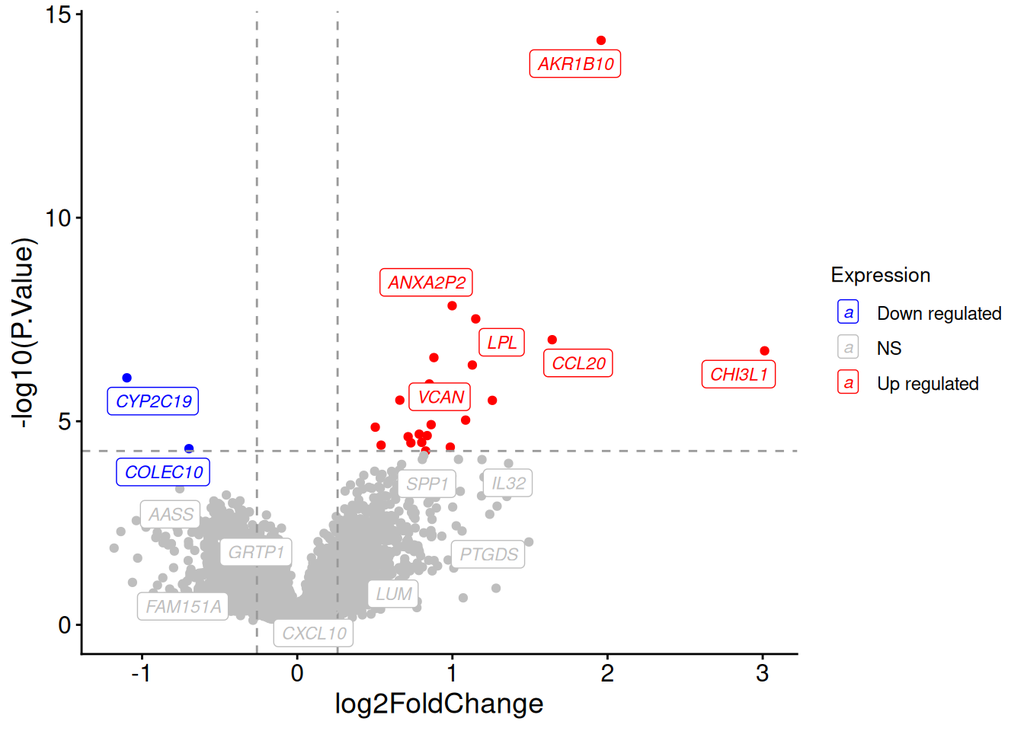

```r
res_tx_normal_alt$volcano
```

## E3. Pathway enrichment analysis (normal ALT)

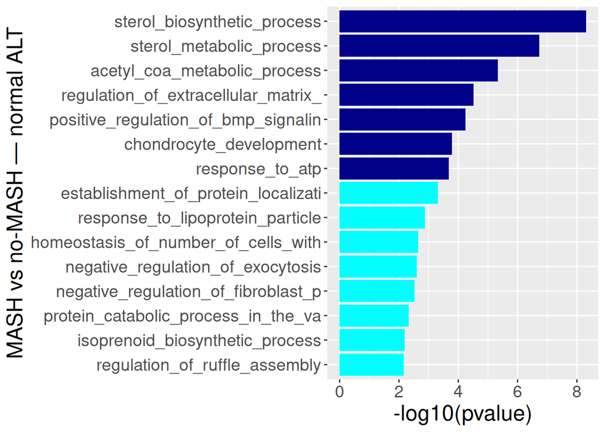

```r
gobp_tx_normal_alt <- enrichMsigdbFct(results      = comp_tx_normal_alt$mstat,
                                      dataBase     = gobp_human,
                                      symbEntrezid = symbEntrezid)

printResultsEnrchHistFct(enrchResults = gobp_tx_normal_alt$resultHist,
                         xlab = "MASH vs no-MASH — normal ALT")
```

```r
rownames(gobp_tx_normal_alt$resultEnrich) <- NULL
sig_pathway_normal_alt <- gobp_tx_normal_alt$resultEnrich[
  gobp_tx_normal_alt$resultEnrich$p.adjust <= 0.05, ]

datatable(
  sig_pathway_normal_alt[, c("ID", "setSize", "NES", "rank", "p.adjust",
                             "n_leading", "leading_edge")],
  options = list(scrollX = TRUE),
  caption = "GO-BP enrichment, normal ALT (FDR <= 0.05)"
) %>%
  formatRound(columns = c("NES", "p.adjust"), digits = 6)
```

|  | ID | setSize | NES | rank | p.adjust | n_leading | leading_edge |
| --- | --- | --- | --- | --- | --- | --- | --- |
| 1 | sterol_biosynthetic_process | 71 | 1.786334507443292 | 3699 | 1.330768835443831e-05 | 34 | ACLY, NPC1L1, LSS, HMGCS1, MVD, SREBF2, NSDHL, ERG28, HSD17B7, CYP51A1, INSIG2, EBP, DHCR7, CES1, INSIG1, ABCG1, SC5D, PRKACA, PRKAA2, CYB5R1, ABCA2, CYP7A1, MSMO1, CYB5R3, PMVK, LIPA, MIR182, APOE, H… |
| 2 | acetyl_coa_metabolic_process | 43 | 1.735572348691209 | 3174 | 0.004188004064246186 | 16 | ACLY, HMGCS1, MVD, GCDH, FASN, AASS, PDHB, AADAT, NUDT8, ACSS1, PMVK, ACOT12, DLAT, DIP2A, PDHA1, HMGCR |
| 3 | positive_regulation_of_bmp_signaling_pathway | 36 | 1.730775899958903 | 4287 | 0.01920074683738952 | 18 | SCUBE3, TBX20, NOTCH2, NEO1, ACVRL1, GDF5, ENG, ILK, SMAD2, ZNF423, UBE2O, MSX2, TWSG1, GPC3, KCP, RBPJ, SULF1, PELO |
| 4 | chondrocyte_development | 32 | 1.700763818156848 | 4686 | 0.03798366840819781 | 15 | SULF2, EXT1, CHST11, GALNT3, SOX9, ECM1, PTHLH, SHOX2, MSX2, SMPD3, BMPR1B, COL27A1, SULF1, MEX3C, COL11A1 |
| 5 | response_to_atp | 29 | 1.696327377293447 | 2629 | 0.03825471910395953 | 11 | P2RX5, TRPM4, CIB2, PANX1, P2RX2, P2RX7, NT5E, ASPH, PKLR, P2RX4, P2RY4 |
| 7 | regulation_of_extracellular_matrix_organization | 66 | 1.579780798896978 | 5752 | 0.01619069829223855 | 32 | LAMA2, LAMB2, ANTXR1, COLGALT1, SOX9, FAP, TIE1, NID1, COL6A1, ABL1, RUNX1, ANGPTL7, RGCC, TGFBR1, TIMP3, IL6, MIR483, EMILIN1, SMAD3, HAS2, MIR21, STAT3, AEBP1, FGFR4, ZNF469, MIR98, CFLAR, IER3IP1, … |
| 10 | sterol_metabolic_process | 164 | 1.527336215525222 | 4241 | 0.0002489451360764667 | 62 | ACLY, NPC1L1, LSS, HMGCS1, MVD, SREBF2, NSDHL, LDLR, ERG28, HSD17B7, CYP51A1, SCP2, CYP2C9, INSIG2, EBP, NFE2L1, DHCR7, CES1, INSIG1, ABCG1, SC5D, PRKACA, PPARD, PRKAA2, CYB5R1, LDLRAP1, LEPR, CYP39A1… |
| 16 | negative_regulation_of_endothelial_cell_proliferation | 66 | 1.505253318964392 | 6708 | 0.03916235079518221 | 37 | CAV1, APOH, AIMP1, VASH1, MIR30E, THBS1, MIR487B, ALOX5, RGCC, SPARC, TGFBR1, ACVRL1, ENG, ATOH8, MEF2C, CCL2, STAT1, MIR483, APOE, MIR494, MIR21, MIR497, SULF1, MIR149, NR2F2, MIR98, MIR126, PTPRM, M… |
| 41 | alcohol_biosynthetic_process | 144 | 1.429251350113958 | 3699 | 0.006386968726166636 | 45 | ACLY, NPC1L1, LSS, HMGCS1, MVD, SREBF2, NSDHL, HSD17B7, CYP51A1, SCP2, INSIG2, EBP, DHCR7, CES1, IP6K3, INSIG1, ABCG1, SC5D, PRKACA, PRKAA2, IPMK, PPIP5K2, ABCA2, CYP7A1, H6PD, MSMO1, CYB5R3, ISYNA1, … |
| 47 | isoprenoid_metabolic_process | 115 | 1.423469723923761 | 3626 | 0.02745398495668965 | 37 | AKR1B10, LPL, CYP2C19, LSS, HMGCS1, MVD, LDLR, DPM3, SCP2, CYP2C9, DPM2, CES1, AKR1B15, ACAT2, CYP3A7, AKR1C3, CES2, CYP3A5, DGAT1, RDH11, DPM1, PMVK, SCPEP1, RBP4, LIPA, ADH6, HMGCR, CYP2S1, AKR1C4, … |

[output cut: 12 more lines]

## E4. Comparison with the whole cohort

```r
whole <- sig_pathway %>%
  transmute(ID,
            NES_whole = round(NES, 3),
            FDR_whole = signif(p.adjust, 3))

normal <- sig_pathway_normal_alt %>%
  transmute(ID,
            NES_normal = round(NES, 3),
            FDR_normal = signif(p.adjust, 3))

comp <- full_join(whole, normal, by = "ID") %>%
  mutate(
    in_whole  = !is.na(NES_whole),
    in_normal = !is.na(NES_normal),
    category = case_when(
       in_whole &  in_normal ~ "Shared biology",
      !in_whole &  in_normal ~ "Newly enriched in normal ALT",
       in_whole & !in_normal ~ "Only in whole cohort",
      TRUE ~ NA_character_
    ),
    interpretation = case_when(
      category == "Shared biology" & abs(NES_normal) > abs(NES_whole) ~
        "Shared biology (more prominent in normal ALT)",
      category == "Shared biology" ~ "Shared biology",
      TRUE ~ category
    )
  ) %>%
  arrange(desc(in_normal), FDR_normal, FDR_whole)

datatable(
  comp %>% select(
    Pathway            = ID,
    `NES (whole)`      = NES_whole,
    `FDR (whole)`      = FDR_whole,
    `NES (normal ALT)` = NES_normal,
    `FDR (normal ALT)` = FDR_normal,
    Interpretation     = interpretation
  ),
  rownames = FALSE,
  caption  = "GO-BP enrichment: whole cohort vs normal ALT — shared and distinct pathways",
  options  = list(pageLength = 15, scrollX = TRUE)
)
```

| Pathway | NES (whole) | FDR (whole) | NES (normal ALT) | FDR (normal ALT) | Interpretation |
| --- | --- | --- | --- | --- | --- |
| sterol_biosynthetic_process | 1.609 | 0.00254 | 1.786 | 1.33e-05 | Shared biology (more prominent in normal ALT) |
| sterol_metabolic_process |  |  | 1.527 | 0.000249 | Newly enriched in normal ALT |
| acetyl_coa_metabolic_process |  |  | 1.736 | 0.00419 | Newly enriched in normal ALT |
| alcohol_biosynthetic_process | 1.349 | 0.0422 | 1.429 | 0.00639 | Shared biology (more prominent in normal ALT) |
| steroid_biosynthetic_process | 1.322 | 0.0464 | 1.389 | 0.0162 | Shared biology (more prominent in normal ALT) |
| regulation_of_extracellular_matrix_organization |  |  | 1.58 | 0.0162 | Newly enriched in normal ALT |
| pyridine_containing_compound_metabolic_process |  |  | 1.403 | 0.0162 | Newly enriched in normal ALT |
| positive_regulation_of_bmp_signaling_pathway |  |  | 1.731 | 0.0192 | Newly enriched in normal ALT |
| isoprenoid_metabolic_process | 1.506 | 0.00222 | 1.423 | 0.0275 | Shared biology |
| regulation_of_small_molecule_metabolic_process |  |  | 1.284 | 0.0318 | Newly enriched in normal ALT |

[output cut: 47 more lines]

# Part F — Liver metabolomics, normal ALT

## F1. Restrict to normal-ALT patients with complete covariates

```r
common_liver <- intersect(work$patient, colnames(liver_data))

m_liver <- work %>%
  filter(patient %in% common_liver, alt_level == "normal",
         !is.na(Age), !is.na(BMI), !is.na(sex_label), !is.na(mash_lab)) %>%
  mutate(
    grp     = factor(mash_lab, levels = c("noMASH", "MASH")),
    sex_bin = ifelse(sex_label == "Female", 0, 1)
  )
rownames(m_liver) <- m_liver$patient

cat("Liver + clinical patients:", length(common_liver),
    "| normal ALT with complete covariates:", nrow(m_liver), "\n")
```

```
## Liver + clinical patients: 290 | normal ALT with complete covariates: 159
```

```r
print(table(m_liver$grp))
```

```
##
## noMASH   MASH
##    139     20
```

## F2. Differential abundance — limma (adjusted for Age, sex, BMI)

```r
x_liver <- as.matrix(liver_data[, m_liver$patient, drop = FALSE])

design_liver <- model.matrix(~ -1 + grp + Age + sex_bin + BMI, data = m_liver)
fit_liver    <- lmFit(x_liver, design_liver)
comp_liver   <- comparisonsLimmaFct(fit_liver, "grpMASH - grpnoMASH",
                                    design_liver, nrow(x_liver))
res_liver    <- printResultsLimmaFct(comp_liver,
                                     topPrintHist = FALSE, topPrintVolc = FALSE)
```

```
## There are 12 differentially expressed features considering threshold 0.05 on adjusted P-values, and 12 when adding the threshold 0.26 on absolute value of log2 Fold Change.
```

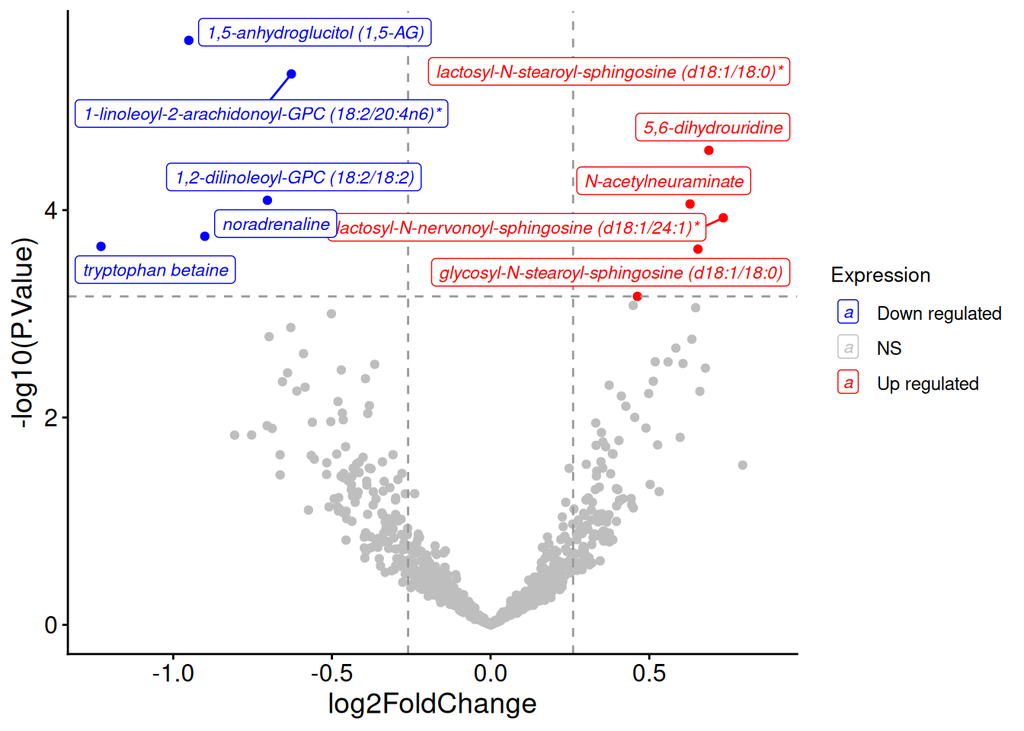

```r
res_liver$volcano
```

```r
datatable(
  res_liver$results[order(res_liver$results$logFC, decreasing = TRUE), ],
  caption = "Liver: MASH vs no-MASH within normal ALT",
  options = list(scrollX = TRUE)
)
```

|  | logFC | FC | adj.P.Val |
| --- | --- | --- | --- |
| lactosyl-N-stearoyl-sphingosine (d18:1/18:0)* | 0.861473 | 1.82 | 0.001343 |
| lactosyl-N-nervonoyl-sphingosine (d18:1/24:1)* | 0.733229 | 1.66 | 0.013853 |
| 5,6-dihydrouridine | 0.687717 | 1.61 | 0.005418 |
| glycosyl-N-stearoyl-sphingosine (d18:1/18:0) | 0.653477 | 1.57 | 0.019427 |
| N-acetylneuraminate | 0.628493 | 1.55 | 0.011885 |
| N2,N2-dimethylguanosine | 0.561497 | 1.48 | 0.024717 |
| taurine | 0.462617 | 1.38 | 0.046252 |
| 1-linoleoyl-2-arachidonoyl-GPC (18:2/20:4n6)* | -0.627874 | 0.65 | 0.001343 |
| 1,2-dilinoleoyl-GPC (18:2/18:2) | -0.703287 | 0.61 | 0.011885 |
| noradrenaline | -0.900505 | 0.54 | 0.018272 |

[output cut: 2 more lines]

## F3. Metabolon annotation

```r
sig_liver <- res_liver$results
idx <- match(rownames(sig_liver), l_chem_details$BIOCHEMICAL)
cat("Unannotated:", sum(is.na(idx)), "/", nrow(sig_liver), "\n")
```

```
## Unannotated: 0 / 12
```

```r
sig_liver$Super_pathway <- l_chem_details$SUPER.PATHWAY[idx]
sig_liver$Sub_pathway   <- l_chem_details$SUB.PATHWAY[idx]
sig_liver$metabolite    <- rownames(sig_liver)
```

## F4. Summary by sub-pathway

```r
sub_sum_liver <- sig_liver %>%
  arrange(desc(abs(logFC))) %>%
  group_by(Super_pathway, Sub_pathway) %>%
  summarise(
    No_sig    = n(),
    No_up     = sum(logFC > 0),
    No_down   = sum(logFC < 0),
    Direction = case_when(
      all(logFC > 0) ~ "all up",
      all(logFC < 0) ~ "all down",
      TRUE ~ paste0(sum(logFC > 0), " up / ", sum(logFC < 0), " down")
    ),
    median_logFC = round(median(logFC), 3),
    median_FC    = round(2^median(logFC), 2),
    best_FDR     = signif(min(adj.P.Val), 3),
    strongest    = paste(head(metabolite, 3), collapse = "; "),
    .groups      = "drop"
  ) %>%
  arrange(desc(No_sig), best_FDR)

datatable(sub_sum_liver, options = list(scrollX = TRUE),
          caption = "Liver: significant metabolites by Metabolon sub-pathway (normal ALT)")
```

|  | Super_pathway | Sub_pathway | No_sig | No_up | No_down | Direction | median_logFC | median_FC | best_FDR | strongest |
| --- | --- | --- | --- | --- | --- | --- | --- | --- | --- | --- |
| 1 | Lipid | Lactosylceramides (LCER) | 2 | 2 | 0 | all up | 0.797 | 1.74 | 0.00134 | lactosyl-N-stearoyl-sphingosine (d18:1/18:0)*; lactosyl-N-nervonoyl-sphingosine (d18:1/24:1)* |
| 2 | Lipid | Phosphatidylcholine (PC) | 2 | 0 | 2 | all down | -0.666 | 0.63 | 0.00134 | 1,2-dilinoleoyl-GPC (18:2/18:2); 1-linoleoyl-2-arachidonoyl-GPC (18:2/20:4n6)* |
| 3 | Carbohydrate | Glycolysis, Gluconeogenesis, and Pyruvate Metabolism | 1 | 0 | 1 | all down | -0.951 | 0.52 | 0.00134 | 1,5-anhydroglucitol (1,5-AG) |
| 4 | Nucleotide | Pyrimidine Metabolism, Uracil containing | 1 | 1 | 0 | all up | 0.688 | 1.61 | 0.00542 | 5,6-dihydrouridine |
| 5 | Carbohydrate | Aminosugar Metabolism | 1 | 1 | 0 | all up | 0.628 | 1.55 | 0.0119 | N-acetylneuraminate |
| 6 | Amino Acid | Tyrosine Metabolism | 1 | 0 | 1 | all down | -0.901 | 0.54 | 0.0183 | noradrenaline |
| 7 | Amino Acid | Tryptophan Metabolism | 1 | 0 | 1 | all down | -1.228 | 0.43 | 0.0194 | tryptophan betaine |
| 8 | Lipid | Hexosylceramides (HCER) | 1 | 1 | 0 | all up | 0.653 | 1.57 | 0.0194 | glycosyl-N-stearoyl-sphingosine (d18:1/18:0) |
| 9 | Nucleotide | Purine Metabolism, Guanine containing | 1 | 1 | 0 | all up | 0.561 | 1.48 | 0.0247 | N2,N2-dimethylguanosine |
| 10 | Amino Acid | Methionine, Cysteine, SAM and Taurine Metabolism | 1 | 1 | 0 | all up | 0.463 | 1.38 | 0.0463 | taurine |

# Session info

```r
#sessionInfo()
```